```yaml
---
title: "Exploratory Data Analysis on CMU Sleep Dataset"
author: "Francisco Javier Abollado"
date: "2024-09-25"
output: html_document
---
```

# 0. Introduction

In this analysis, we perform an exploratory data analysis (EDA) on the CMU Sleep dataset. The purpose is to examine key variables, handle missing data, and investigate relationships between sleep patterns and GPA across different cohorts and universities. The analysis will be presented with a combination of summary statistics, visualizations, and correlation studies.

# 1. Load Data

```r
# Load necessary libraries
library(dplyr)
```

```r
library(tidyr)
library(ggplot2)


df <- read.csv('cmu-sleep.csv')
```

# 2. Initial Data Inspection

We begin by inspecting the structure and summary statistics of the dataset to understand its contents and identify potential issues with the data.

```r
# View basic information about the dataset
str(df)
```

```
## 'data.frame':    634 obs. of  15 variables:
##  $ subject_id           : int  185 158 209 102 174 184 255 265 343 137 ...
##  $ study                : int  5 5 5 5 5 5 5 5 5 5 ...
##  $ cohort               : chr  "lac1" "lac1" "lac1" "lac1" ...
##  $ demo_race            : int  1 0 1 0 1 1 1 1 1 1 ...
##  $ demo_gender          : int  1 1 1 1 1 1 1 1 0 1 ...
##  $ demo_firstgen        : int  0 0 0 1 0 0 0 0 0 0 ...
##  $ bedtime_mssd         : num  0.117 0.142 1.529 0.13 0.13 ...
##  $ TotalSleepTime       : num  432 392 344 393 423 ...
##  $ midpoint_sleep       : num  459 364 561 416 369 ...
##  $ frac_nights_with_data: num  0.862 1 0.793 1 0.655 ...
##  $ daytime_sleep        : num  24.2 13.1 15 54.6 10.5 ...
##  $ cum_gpa              : num  3 3.66 3.57 3.61 3.21 3.2 3.4 3.86 3.79 3.53 ...
##  $ term_gpa             : num  3.38 2.6 3.07 3.56 4 3.36 3.19 3.28 3.5 2.55 ...
##  $ term_units           : int  73 64 63 61 61 60 60 60 60 59 ...
##  $ Zterm_units_ZofZ     : num  4.06 2.48 2.31 1.96 1.96 ...
```

```r
head(df)
```

```
##   subject_id study cohort demo_race demo_gender demo_firstgen bedtime_mssd
## 1        185     5   lac1         1           1             0    0.1167269
## 2        158     5   lac1         0           1             0    0.1416808
## 3        209     5   lac1         1           1             0    1.5292895
## 4        102     5   lac1         0           1             1    0.1301485
## 5        174     5   lac1         1           1             0    0.1301809
## 6        184     5   lac1         1           1             0    0.2094830
##   TotalSleepTime midpoint_sleep frac_nights_with_data daytime_sleep cum_gpa
## 1       432.2000       458.6600             0.8620690      24.16000    3.00
## 2       391.9310       364.4655             1.0000000      13.13793    3.66
## 3       344.3043       560.8913             0.7931034      14.95652    3.57
## 4       392.6207       416.4828             1.0000000      54.55172    3.61
## 5       423.4211       368.7632             0.6551724      10.52632    3.21
## 6       397.4000       353.5800             0.8620690      22.36000    3.20
##   term_gpa term_units Zterm_units_ZofZ
## 1     3.38         73         4.055295
## 2     2.60         64         2.482534
## 3     3.07         63         2.307783
## 4     3.56         61         1.958281
## 5     4.00         61         1.958281
## 6     3.36         60         1.783529
```

```r
summary(df)
```

```
##    subject_id          study          cohort            demo_race
##  Min.   :    1.0   Min.   :1.000   Length:634         Min.   :0.000
##  1st Qu.:  178.0   1st Qu.:2.000   Class :character   1st Qu.:1.000
##  Median :  358.5   Median :3.000   Mode  :character   Median :1.000
##  Mean   :13005.9   Mean   :3.181                      Mean   :0.812
##  3rd Qu.:  592.8   3rd Qu.:4.000                      3rd Qu.:1.000
##  Max.   :99978.0   Max.   :5.000                      Max.   :1.000
##                                                       NA's   :1
##   demo_gender     demo_firstgen     bedtime_mssd       TotalSleepTime
##  Min.   :0.0000   Min.   :0.0000   Min.   : 0.004505   Min.   :194.8
##  1st Qu.:0.0000   1st Qu.:0.0000   1st Qu.: 0.074694   1st Qu.:366.9
##  Median :1.0000   Median :0.0000   Median : 0.135007   Median :400.4
##  Mean   :0.5832   Mean   :0.1667   Mean   : 0.451688   Mean   :397.3
##  3rd Qu.:1.0000   3rd Qu.:0.0000   3rd Qu.: 0.291698   3rd Qu.:430.1
##  Max.   :1.0000   Max.   :2.0000   Max.   :20.849225   Max.   :587.7
##  NA's   :3        NA's   :4
##  midpoint_sleep  frac_nights_with_data daytime_sleep        cum_gpa
##  Min.   :247.1   Min.   :0.2143        Min.   :  2.269   Min.   :1.210
##  1st Qu.:345.2   1st Qu.:0.8214        1st Qu.: 23.098   1st Qu.:3.232
##  Median :388.2   Median :0.9322        Median : 34.982   Median :3.558
##  Mean   :398.7   Mean   :0.8674        Mean   : 41.164   Mean   :3.466
##  3rd Qu.:437.7   3rd Qu.:1.0000        3rd Qu.: 51.249   3rd Qu.:3.790
##  Max.   :724.7   Max.   :1.0000        Max.   :292.304   Max.   :4.000
##
##     term_gpa       term_units    Zterm_units_ZofZ
##  Min.   :0.350   Min.   : 5.00   Min.   :-3.98252
##  1st Qu.:3.233   1st Qu.:15.00   1st Qu.:-0.55104
##  Median :3.556   Median :17.00   Median : 0.04121
##  Mean   :3.450   Mean   :29.39   Mean   : 0.00000
##  3rd Qu.:3.810   3rd Qu.:48.00   3rd Qu.: 0.56027
##  Max.   :4.000   Max.   :73.00   Max.   : 4.05529
##                  NA's   :147     NA's   :147
```

# 3. Data Preprocessing

## 3.1 Correct Data Types

```r
# Convert relevant columns to factor type
df$cohort <- factor(df$cohort)
df$study <- factor(df$study)
df$demo_race <- factor(df$demo_race)
df$demo_gender <- factor(df$demo_gender)
df$demo_firstgen <- factor(df$demo_firstgen)

# Store factor columns for reference
factor_names = c("cohort", "study", "demo_race", "demo_gender", "demo_firstgen")
```

## 3.2 Add Study-Specific Information

We will enrich the dataset by adding additional information about the study, including the university and semester.

```r
# Create a mapping dataframe for study details
df_mapping <- data.frame(
    study = factor(1:5),
    university = factor(c("Carnegie Mellon", "Washington", "Washington", "Notre Dame", "Carnegie Mellon")),
    semester = factor(c("Spring 2018", "Spring 2018", "Spring 2019", "Spring 2016", "Spring 2017"))
)

# Join the mapping information to the main dataset
df <- df %>% left_join(df_mapping, by="study")
```

# 4. Handling Missing Data

We first check for missing values across all columns and identify columns with significant amounts of missing data.

```r
# Check for missing values in the dataset
colSums(is.na(df))
```

```
##            subject_id                 study                cohort
##                     0                     0                     0
##             demo_race           demo_gender         demo_firstgen
##                     1                     3                     4
##          bedtime_mssd        TotalSleepTime        midpoint_sleep
##                     0                     0                     0
## frac_nights_with_data         daytime_sleep               cum_gpa
##                     0                     0                     0
##              term_gpa            term_units      Zterm_units_ZofZ
##                     0                   147                   147
##            university              semester
##                     0                     0
```

## 4.1 Strategy for Missing Data

We will create two versions of the dataset:

- `df.main`: A version excluding these two columns and with no missing values.
- `df.clean`: A version with all columns but no missing values.

```r
# Create two versions of the dataset
df.main <- df %>% select(-term_units, -Zterm_units_ZofZ) %>% drop_na()
df.clean <- df %>% drop_na()
```

# 5. Outliers

No that we have all the numeric values without any Nan values, we are going to check any possible outliers around the dataset. For that we are going to create a function that substruct all the values that are `n` variance far from the mean.

```r
numeric_cols <- names(df.main)[sapply(df.main, is.numeric)]
df.numeric <- df.main[, numeric_cols]

extract_outliers <- function (df, n, returndf=TRUE, print=FALSE){

  # Assuming 'df' is your dataframe
  # Calculate Z-scores
  z_scores <- as.data.frame(scale(df))

  # Detect outliers (absolute z-scores > 3)
  outliers <- abs(z_scores) > n

  # Remove rows where any column has an outlier
  df_no_outliers <- df[!rowSums(outliers), ]

  # Print the shape (dimensions) of the data before and after removing outliers
  cat("\nFor n = ", n, ":\n")
  cat("Data shape before removing outliers:", dim(df), "\n")
  cat("Data shape after removing outliers:", dim(df_no_outliers), "\n")

  if (returndf){
    return(df_no_outliers)
  }
}

extract_outliers(df.numeric, 3, returndf=FALSE, print=TRUE)
```

```
##
## For n =  3 :
## Data shape before removing outliers: 626 8
## Data shape after removing outliers: 560 8
```

```r
extract_outliers(df.numeric, 5, returndf=FALSE, print=TRUE)
```

```
##
## For n =  5 :
## Data shape before removing outliers: 626 8
## Data shape after removing outliers: 616 8
```

```r
extract_outliers(df.numeric, 8, returndf=FALSE, print=TRUE)
```

```
##
## For n =  8 :
## Data shape before removing outliers: 626 8
## Data shape after removing outliers: 622 8
```

As we can see, with `n = 8`, very few outliers are removed, making the criterion too strict. Conversely, with `n = 3`, we remove too many data points, which seems excessive and could result in the loss of valuable information. Therefore, I will choose an intermediate value of `n = 5` for this case. This strikes a balance by removing some outliers without discarding too much data that might be important for the analysis.

```r
df.numeric <- extract_outliers(df.numeric, 5)
```

```
##
## For n =  5 :
## Data shape before removing outliers: 626 8
## Data shape after removing outliers: 616 8
```

Also for this we assumed that the data is moving in normal distribution in order to find outliers. We are going to have a brief look at their real distributions:

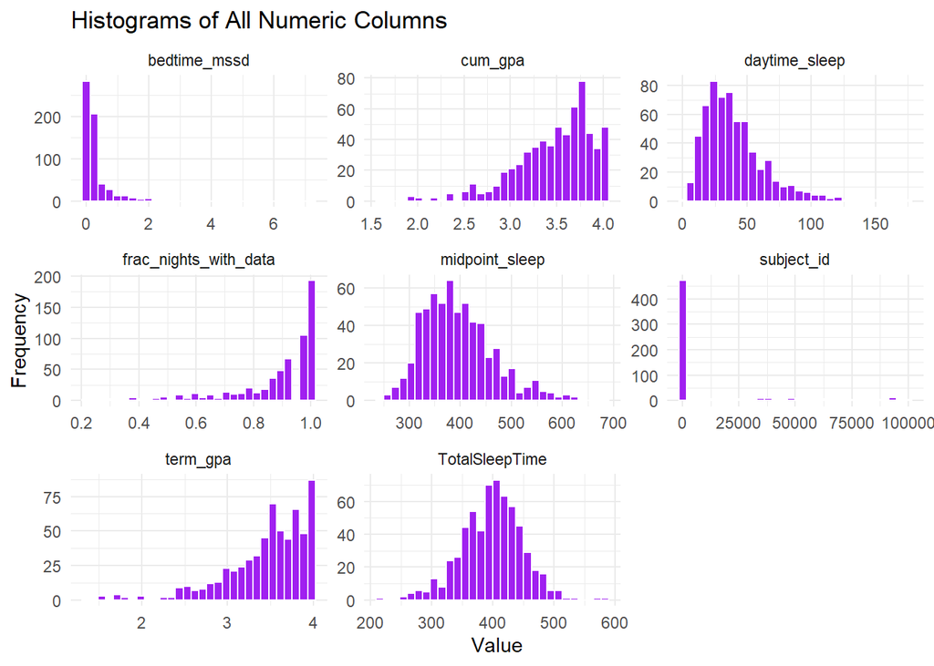

```r
df.numeric %>%
  pivot_longer(cols = everything(), names_to = "key", values_to = "value") %>%
  ggplot(., aes(x = value)) +
    geom_histogram(bins = 30, fill = "purple", color = "white") +
    facet_wrap(~key, scales = "free") +
    theme_minimal() +
    labs(title = "Histograms of All Numeric Columns", x = "Value", y = "Frequency")
```

## 5.1 Observations:

We observe that not all the data is normal distributed, therefore that previous simple approach that we did before is not really a good solution to select the outliers. We are going to study a bit deeper each column and after it select an option to work with these outliers.

## 5.3 Algorithm

We need to ensure that the rows remain aligned correctly by using the common row indices to merge the data back together, preserving only the rows that are present in all cleaned parts.

To handle this correctly, we will:

- Use a common unique identifier to keep track of the rows, for that we will create a new column names `index` as `subject_id` is not unique.
- Perform inner joins on the cleaned datasets to ensure that only the rows present in all parts are retained.

```r
df.numeric$index <- 1:dim(df.numeric)[1]

# Function to remove outliers using Z-score method
remove_outliers_zscore <- function(df, threshold = 5) {
  z_scores <- scale(df)  # Compute Z-scores
  df_clean <- df[!rowSums(abs(z_scores) > threshold), ]  # Remove rows where Z-score is above the threshold
  return(df_clean)
}

# Function to remove outliers using IQR method
remove_outliers_iqr <- function(df, tail="right") {
  Q1 <- apply(df, 2, quantile, 0.2, na.rm = TRUE)  # First quartile (25th percentile)
  Q3 <- apply(df, 2, quantile, 0.8, na.rm = TRUE)  # Third quartile (75th percentile)
  IQR <- Q3 - Q1  # Interquartile range

  # Define lower and upper bounds for outlier detection
  if (tail == "right"){
    lower_bound <- min(df)
    upper_bound <- Q3 + 5 * IQR
  }
  else {
    lower_bound <- Q1 - 5 * IQR
    upper_bound <- max(df)
  }

  # Remove rows with outliers based on IQR
  df_clean <- df[!rowSums(df < lower_bound | df > upper_bound), ]
  return(df_clean)
}

# Create lists of columns that need each method
columns_zscore <- c("TotalSleepTime", "midpoint_sleep", "daytime_sleep")
columns_iqr_lefttail <- c("cum_gpa", "term_gpa")
columns_iqr_righttail <- c("bedtime_mssd")

# Apply Z-score method to specific columns
df_zscore <- df.numeric %>%
  select(index, all_of(columns_zscore)) %>%  # Include the unique identifier
  remove_outliers_zscore()

# Apply IQR method to specific columns
df_iqr_left <- df.numeric %>%
  select(index, all_of(columns_iqr_lefttail)) %>%
  remove_outliers_iqr(., tail="left")
df_iqr_right <- df.numeric %>%
  select(index, all_of(columns_iqr_righttail)) %>%
  remove_outliers_iqr(., tail="right")

# Keep the other columns that do not need outlier detection
columns_no_outliers <- setdiff(names(df.numeric), c(columns_zscore, columns_iqr_lefttail, columns_iqr_righttail))
df_no_outliers <- df.numeric %>%
  select(all_of(columns_no_outliers))

# Perform inner join on subject_id to ensure only rows present in all parts are retained
df.numeric.clean <- df_no_outliers %>%
  inner_join(df_zscore, by = "index") %>%
  inner_join(df_iqr_left, by = "index") %>%
  inner_join(df_iqr_right, by = "index")

# Final result: cleaned dataframe with outliers removed
print("Data after outlier removal:")
```

```
## [1] "Data after outlier removal:"
```

```r
cat("\n - zscores: ", dim(df_zscore))
```

```
##
##  - zscores:  615 4
```

```r
cat("\n - iqr-left: ", dim(df_iqr_left))
```

```
##
##  - iqr-left:  616 3
```

```r
cat("\n - iqr-right: ", dim(df_iqr_right))
```

```
##
##  - iqr-right:  309 2
```

```r
cat("\n - clean: ", dim(df.numeric.clean))
```

```
##
##  - clean:  308 9
```

We can play with this numbers. The Z-scores as 5 looks reasonable and doesn’t get rid of many values. Also the irq-left works fine, while the iqr-right drop too many columns. That’s because of the `bedtime_mssd` values, that are extremely skew. We can solve this by increasing the value or leave it like that depending on the strictness of the analyst, but for now we are going to continue with EDA.

# 6. Exploratory Data Analysis (EDA)

Prior to any analysis, we are going to do a simple scatter-plot visualization the data related with the term GPA as our target value.

```r
library(tidyr)
target_var <- "term_gpa"
df_long <- pivot_longer(df.numeric ,cols = c(-target_var, -subject_id, -index), names_to = "variable", values_to = "value") %>% select(-subject_id, -index)
```

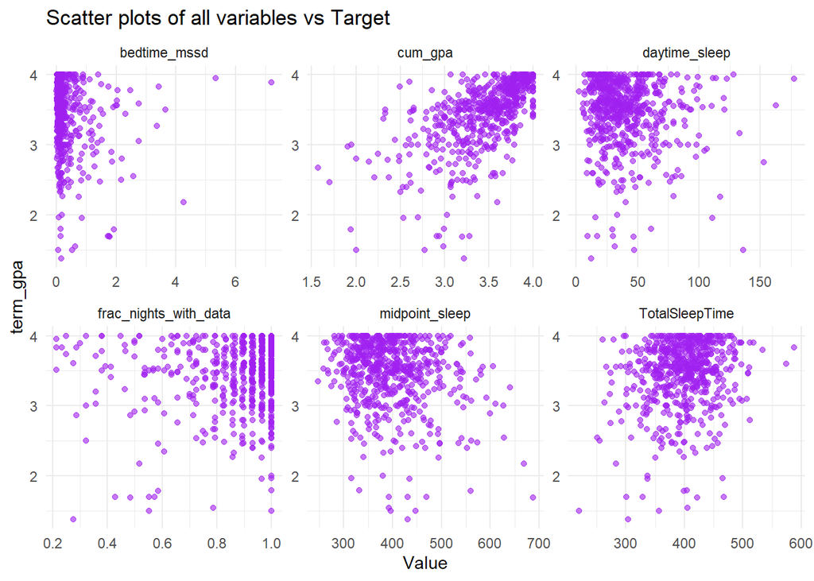

```r
ggplot(df_long, aes(x = value, y = .data[[target_var]])) +
    geom_point(color="purple", alpha=0.6) +
    facet_wrap(~ variable, scales = "free") +
    labs(x = "Value", y = target_var, title = "Scatter plots of all variables vs Target") +
    theme_minimal()
```

## 6.1 How are GPA scores distributed across the students?

We are going to have a brief look at the GPA distributions along Studies and Gender. We’ll find out that basically there is no big difference between different studies and gender, as they all have a big pick at GPA > 3.

### 6.1.1 GPA Distribution Across Studies

We begin by examining the distribution of `term_gpa` across different studies.

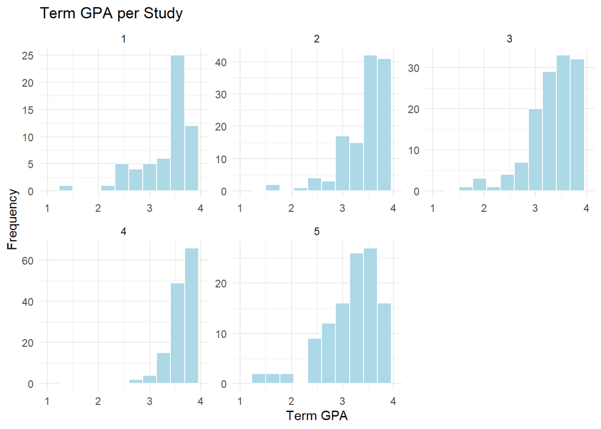

```r
# Histogram of Term GPA per study
ggplot(df.main, aes(x = term_gpa)) +
  geom_histogram(bins = 12, fill = "lightblue", color = "white") +
  labs(x = "Term GPA", y = "Frequency", title = "Term GPA per Study") +
  xlim(1, 4) +
  facet_wrap(~study, scales = 'free') +
  theme_minimal()
```

### 6.1.2 GPA Distribution Across Genders

Next, we explore the distribution of GPA between male and female students.

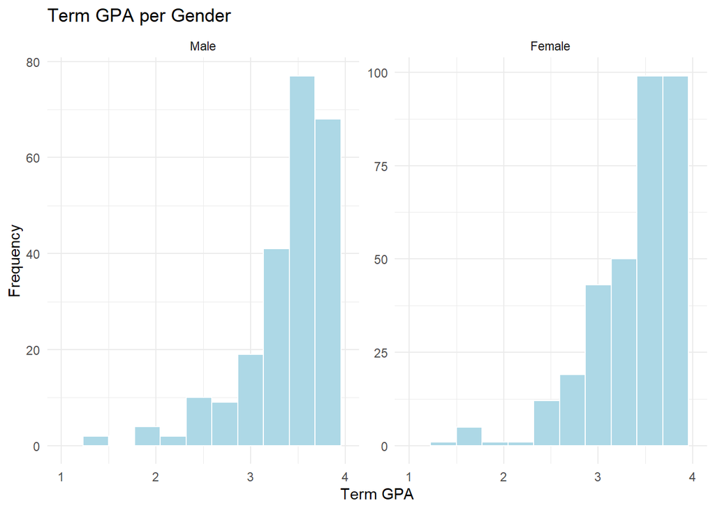

```r
# Histogram of Term GPA per gender
ggplot(df.main, aes(x = term_gpa)) +
  geom_histogram(bins = 12, fill = "lightblue", color = "white") +
  labs(x = "Term GPA", y = "Frequency", title = "Term GPA per Gender") +
  xlim(1, 4) +
  facet_wrap(~demo_gender, scales = 'free', labeller = as_labeller(c("0" = "Male", "1" = "Female"))) +
  theme_minimal()
```

## 6.2 Analyzing the Relationship Between Sleep Patterns and Academic Performance by sections

In this analysis, we are investigating how students’ sleep patterns, measured in midpoint sleep sections, are distributed across different GPA ranges. To ensure that the overall distribution of sleep times doesn’t affect the results, we first normalize the data by calculating the percentage of students in each GPA section within each sleep category. Then, we further normalize those percentages within each GPA range, ensuring that each sleep section is equally represented across GPA categories. This approach helps us focus on how sleep habits within each GPA group are distributed, removing any bias caused by the fact that certain sleep sections (like 5am-6am) might generally have more people.

##### How the Plot Was Created:

1. **Step 1 - Binning GPAs and Sleep Times**: We divided the `term_gpa` into five categories: 0-2, 2-3, 3-3.3, 3.3-3.7, and 3.7-4. The `midpoint_sleep` variable was also categorized into sleep sections based on the midpoint of when the students reported sleeping (e.g., 3am-4am, 4am-5am).
2. **Step 2 - First Normalization**: For each sleep section within each GPA range, we calculated the percentage of students in that group, allowing us to understand the distribution of sleep patterns across all GPA ranges.
3. **Step 3 - Second Normalization**: We further normalized the data within each GPA range to account for the varying numbers of students in each sleep section. This ensures that sections with more students overall do not dominate the plot, giving us a clearer picture of how sleep patterns relate to GPA.
4. **Step 4 - Visualization**: Finally, we created a series of bar plots to visualize the percentage of students in each sleep section for each GPA range, using a consistent y-axis (percentage) across all plots. Each panel represents a different GPA range, showing the normalized distribution of students across sleep sections.

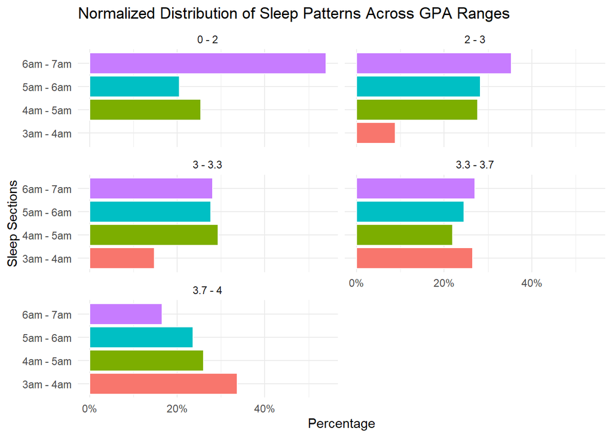

```r
library(ggplot2)
library(dplyr)

# Step 1: Create GPA sections (bins)
df.main$gpa_sections <- cut(df.main$term_gpa, breaks = c(0, 2, 3, 3.3, 3.7, 4), labels = c("0 - 2", "2 - 3", "3 - 3.3", "3.3 - 3.7", "3.7 - 4"), right = FALSE)

# Step 2: Create Sleep Sections if not already done
df.main$midpoint_sleep_sections <- cut(df.main$midpoint_sleep, breaks = c((0:2)*120, (5:8)*60), labels = c("11pm - 1am", "1am - 3am", "3am - 4am", "4am - 5am", "5am - 6am", "6am - 7am"), right = FALSE)

# Step 3: Calculate percentages of people in each GPA section and sleep section
df_percent <- df.main %>%
  group_by(midpoint_sleep_sections, gpa_sections) %>%
  summarise(count = n()) %>% na.omit() %>%
  mutate(percentage_first = count / sum(count) * 100) %>%
  group_by(gpa_sections) %>%
  mutate(percentage_final = percentage_first / sum(percentage_first) * 100)
# Step 4: Plot barplots for each GPA section
ggplot(df_percent, aes(x = percentage_final, y = midpoint_sleep_sections, fill = midpoint_sleep_sections)) +
  geom_bar(stat = "identity", color = "white") +
  facet_wrap(~gpa_sections, ncol = 2) +  # One plot for each GPA section
  labs(y = "Sleep Sections", x = "Percentage", title = "Normalized Distribution of Sleep Patterns Across GPA Ranges") +
  scale_x_continuous(labels = scales::percent_format(scale = 1)) +  # Show y-axis as percentage
  theme_minimal() +
  theme(legend.position = "none")  # Remove legend as it's not needed
```

By normalizing the data twice, we were able to remove any bias caused by differing numbers of students in each sleep section, allowing for a more direct comparison of sleep habits across GPA ranges. This analysis highlights potential connections between earlier sleep times and higher academic achievement.

## 6.3 How does the number of units and sleep time affect academic performance across universities?

### 6.3.1 Sleep time and GPA Increase

We calculate the change in GPA and examine its relationship with sleep time across different universities.

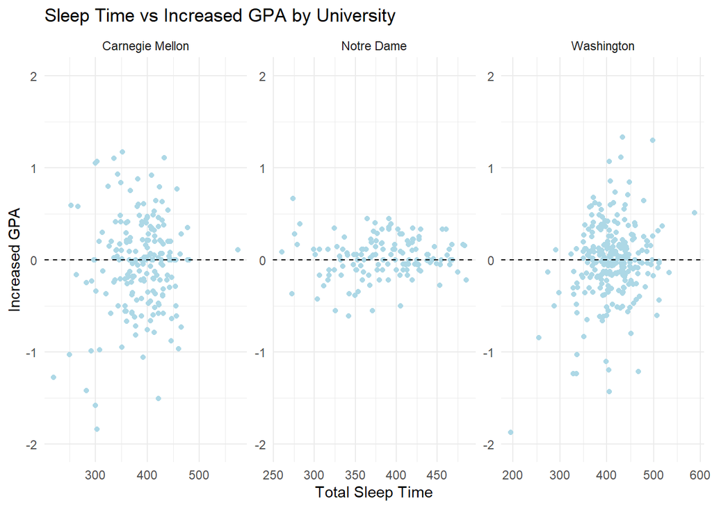

```r
# Calculate GPA increase
df.main$increased_GPA <- df.main$term_gpa - df.main$cum_gpa

# Scatter plot of sleep time vs increased GPA per university
ggplot(df.main, aes(x = TotalSleepTime, y = increased_GPA)) +
  geom_point(color = "lightblue") +
  geom_hline(yintercept = 0, linetype = "dashed", color = "black") +
  ylim(-2, 2) +
  labs(x = "Total Sleep Time", y = "Increased GPA", title = "Sleep Time vs Increased GPA by University") +
  facet_wrap(~university, scales = 'free') +
  theme_minimal()
```

### 6.3.2 Sleep Time, Number of Units and Increased GPA

We now examine the relationship between the number of units taken and the total sleep time, per university.

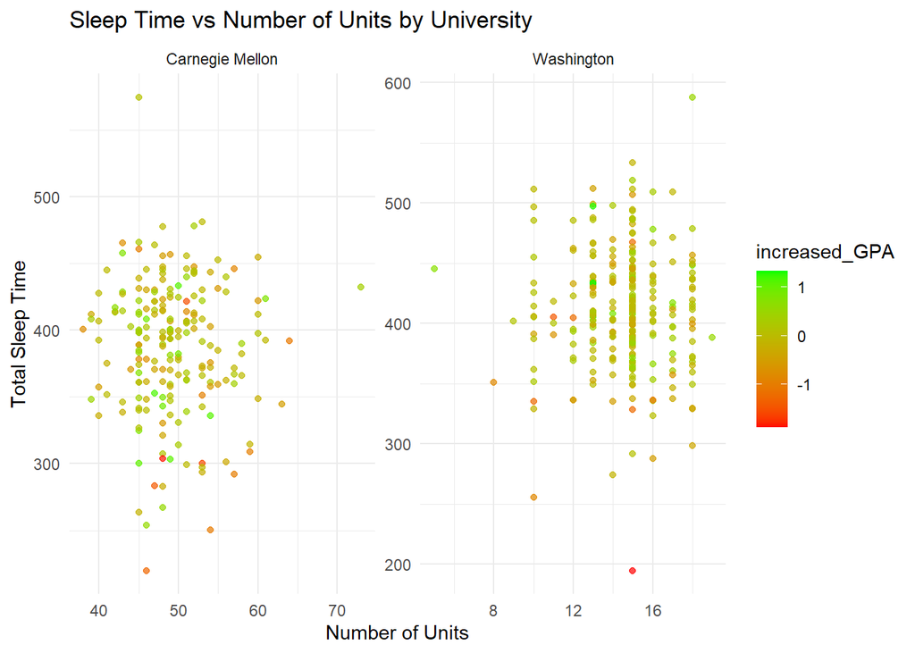

```r
# Scatter plot of sleep time vs number of units
df.clean$increased_GPA <- df.clean$term_gpa - df.clean$cum_gpa

ggplot(df.clean, aes(x = term_units, y = TotalSleepTime, color = increased_GPA)) +
  geom_point(alpha=0.7) +
  labs(x = "Number of Units", y = "Total Sleep Time", title = "Sleep Time vs Number of Units by University") +
  facet_wrap(~university, scales = 'free') +
  scale_color_gradient(low = "red", high = "green") +  # Color gradient from blue to red
  theme_minimal()
```

We can see that there is not much of a relationship with this variables. Just some outliers at the bottom of the `TotalSleepTime` with usually a negative increased GPA, meaning that (at least in this sample) people who sleep the least usually decrease their GPA score.

## 6.4 Impact of Prior Academic Performance on New Grades in a University Transition

We will examine the differences between the `cumulative GPA` and the new `term_gpa`, comparing these across universities, as each institution presents varying levels of academic difficulty.

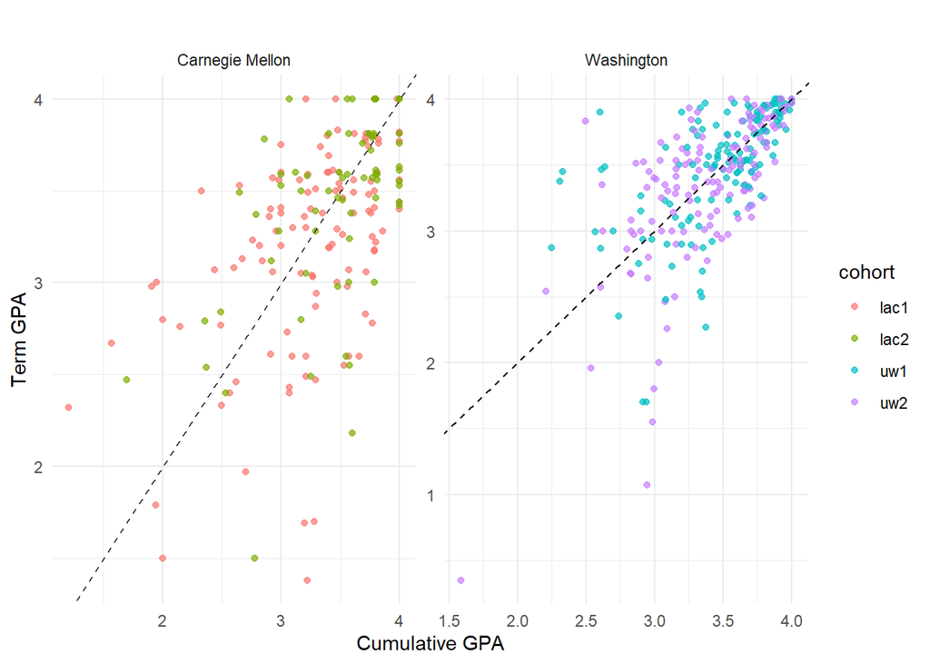

```r
ggplot(df.clean, aes(x = cum_gpa, y = term_gpa, color = cohort)) +
  geom_point(alpha=0.7) +
  geom_abline(slope = 1, intercept = 0, color = "black", linetype = "dashed") +
  labs(x = "Cumulative GPA", y = "Term GPA", title = "") +
  facet_wrap(~university, scales = 'free') +
  #scale_color_gradient(low = "red", high = "green") +  # Color gradient from blue to red
  theme_minimal()
```

This scatter plot shows the relationship between **Cumulative GPA** (GPA prior to the academic year) and **Term GPA** (GPA during the current term) for students from **Carnegie Mellon** and **Washington** universities. The diagonal dashed line represents **no improvement** — points above the line indicate a **positive improvement** in GPA, while points below the line show a **negative change**.

- **Above the line**: Students improved their GPA compared to their previous cumulative GPA.
- **On the line**: Students maintained similar GPA performance.
- **Below the line**: Students’ GPA declined during the term.

The **Washington** students are mostly clustered around or above the line, indicating consistent or slightly improved performance. In contrast, **Carnegie Mellon** students show more variability, with some making significant improvements and others showing declines.

Also an interesting observation is that students with a cumulative GPA above 3.5 in Washington University are much more consistent than CMU students in the meaning of maintaining or even improving their grades.

## 6.5 Correlation Analysis

We calculate the correlation matrix between numerical variables and visualize it using a heatmap.

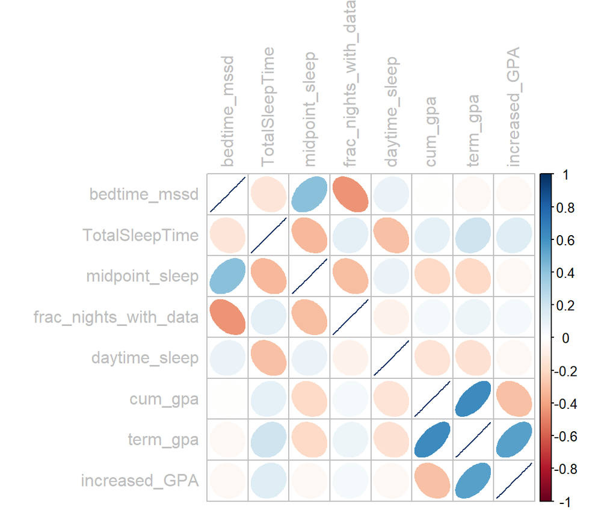

```r
suppressMessages(library(corrplot))

# Select numeric columns excluding 'subject_id'
numeric_cols <- sapply(df.main, is.numeric)
numeric_cols <- setdiff(names(numeric_cols[numeric_cols]), "subject_id")

# Calculate the correlation matrix
cor_matrix <- cor(df.main[, numeric_cols], use = "complete.obs")
cor_matrix %>% corrplot(., method="ellipse", type="full", tl.col="gray")
```

## 6.6 Sleep Time by Study and Gender

Finally, we compare the distribution of sleep time across different studies and between genders to check if there is a major difference between some of them.

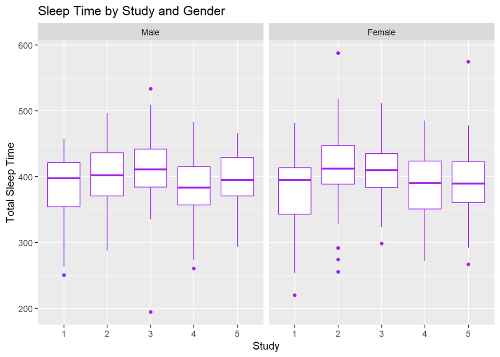

```r
# Boxplot of sleep time by study and gender
ggplot(df.main, aes(x = study, y = TotalSleepTime)) +
  geom_boxplot(color="purple") +
  facet_wrap(~demo_gender, scales = "free_x", labeller = as_labeller(c("0" = "Male", "1" = "Female"))) +
  labs(x="Study", y="Total Sleep Time", title="Sleep Time by Study and Gender")
```

Is not possible to find any gender difference on the data, both look similar obviously with some random changes as every person is different. Also between different studies we observed similar results.

# 7. Conclusion

In this analysis, we explored several aspects of the dataset, including the distribution of GPA across different studies and genders, the relationship between sleep time and GPA, and the correlations between key numerical variables. We handled missing data appropriately by creating two versions of the dataset and focused our analysis on meaningful relationships. The visualizations and correlation analysis provided deeper insights into the sleep and academic performance patterns of students.